# quickforecasts

Caroline Colijn

09/03/2020

## Setup

Read in the data

```r
confirmed = read.csv("time_series_19-covid-Confirmed.csv", stringsAsFactors = F)
deaths=read.csv("time_series_19-covid-Deaths.csv", stringsAsFactors = F)
recov = read.csv("time_series_19-covid-Recovered.csv", stringsAsFactors = F)
```

Extract dates from the column heads

```r
colstr=colnames(confirmed)[5:ncol(confirmed)]
dstr=vapply(colstr, function(x) substr(x, start = 2, stop = nchar(x)), FUN.VALUE="hi")
dates=as.Date(dstr, format = "%m.%d.%y")
N=ncol(confirmed)
```

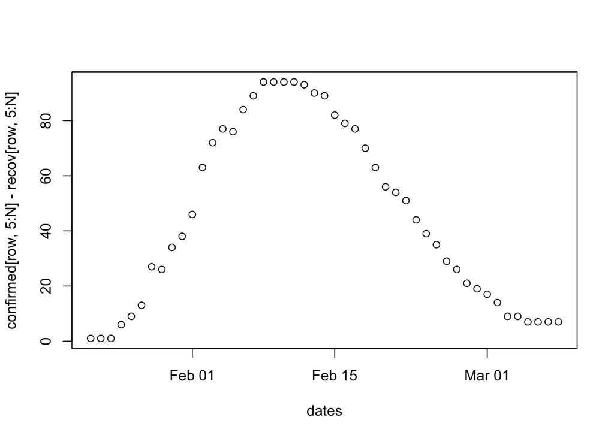

```r
row=25
plot(dates,confirmed[row,5:N]-recov[row,5:N])
```

Set up some names

```r
airChina_names=c('Beijing', 'Shanghai', 'Guangdong', 'Henan', 'Jiangsu', 'Liaoning', 'Shandong', 'Fujian')
airCountries=c('Japan', 'South Korea', 'Germany', 'Taiwan', 'France', 'India', 'UK', 'Hong Kong')
china_confirmed = confirmed[which(confirmed$Province %in% airChina_names),]
china_death = deaths[which(confirmed$Province %in% airChina_names),]
china_rec = recov[which(confirmed$Province %in% airChina_names),]
```

Start by examining the total for China, then move on to forecasting other groups

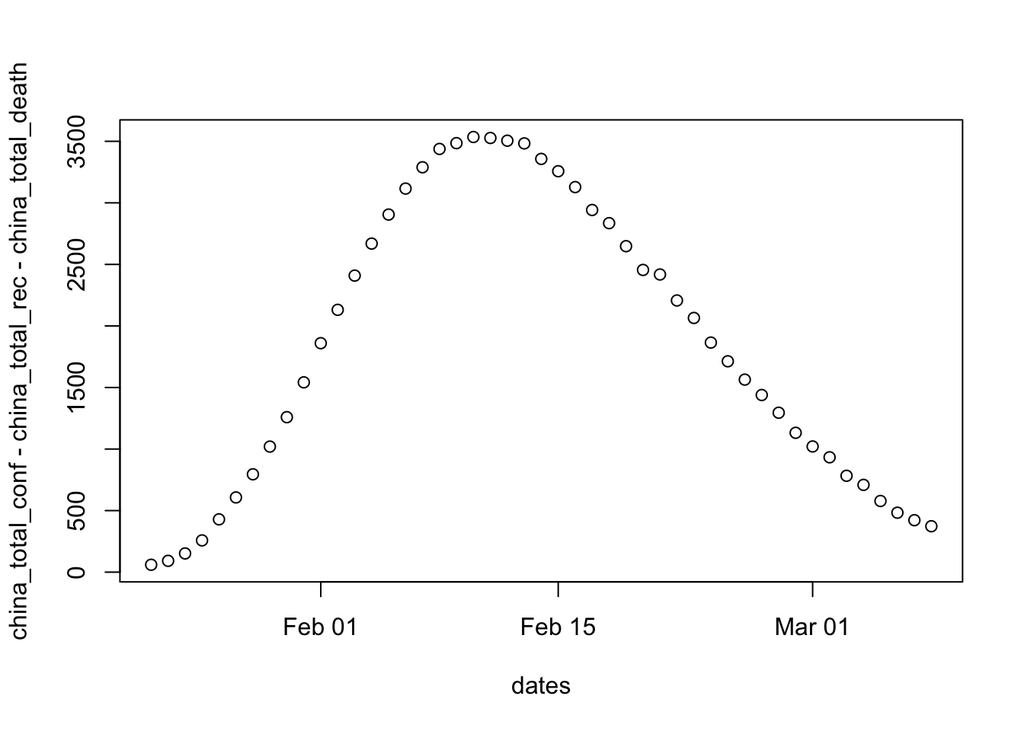

```r
china_total_conf = colSums(china_confirmed[,5:N])
china_total_rec = colSums(china_rec[,5:N])
china_total_death=colSums(china_death[,5:N])
plot(dates,china_total_conf-china_total_rec-china_total_death)
```

If I forecast that it will be essentially 0. Is that right? Or do we think that there remains travel out of Wuhan and into the rest of China? Hm.

Get intuition from a ggplottable df

```r
conf = melt(confirmed, id.vars = c("Province", "Region", "Lat","Long"),
                measure.vars = colnames(confirmed)[5:N])
recsimp = melt(recov, id.vars = c("Province", "Region", "Lat","Long"),
                measure.vars = colnames(confirmed)[5:N])
deathsimp = melt(deaths, id.vars = c("Province", "Region", "Lat","Long"),
                measure.vars = colnames(confirmed)[5:N])
conf$variable=as.Date(conf$variable, format = "X%m.%d.%y")
colnames(conf)=c("Province","Region","Lat","Long","date","cases")
allsimp=conf; allsimp$prev = conf$cases-recsimp$value - deathsimp$value
allsimp$deaths = deathsimp$value
allsimp$recovered = recsimp$value
```

```r
ggplot(data=filter(allsimp,Region %in% "South Korea"), aes(x=date, y=prev, colour=Region))+geom_point()
```

[output not shown]

I will need a much simpler kind of forecast. MUCH Simpler (see fail SIR below).

For this I should aggregate in the same way that Nicola is going to: Mainland China, etc. And use something closer to extrapolation than to modelling.

To aggregate or not to aggregate

- the Chinese airports whose names are in that list
- mainland china all
- S. Korea
- US
- everything else

Set up names and things to match

```r
extractPrevRegion = function(thisname) {
# make a simple data frame with date, cases, deaths, rec, prev, numerical data
if (thisname %in% confirmed$Region) {
conftmp=confirmed[which(confirmed$Region %in% thisname), ]
rectmp=recov[which(confirmed$Region %in% thisname), ]
deathtmp=deaths[which(confirmed$Region %in% thisname), ]
} else {if (thisname %in% confirmed$Province) {
  conftmp=confirmed[which(confirmed$Province %in% thisname), ]
rectmp=recov[which(confirmed$Province %in% thisname), ]
deathtmp=deaths[which(confirmed$Province %in% thisname), ]
}}
if (nrow(conftmp) > 1) {
  cases=colSums(conftmp[,5:ncol(conftmp)])
  recs = colSums(rectmp[,5:ncol(rectmp)])
  deas=colSums(deathtmp[,5:ncol(deathtmp)])
} else {cases=conftmp[5:ncol(conftmp)]
  recs=rectmp[5:ncol(rectmp)]
  deas=deathtmp[5:ncol(deathtmp)]
}
return(prevs=cases-recs-deas)
}
```

```r
getForecast=function(prevs, nDays=10, lastDay=55,mode="poly") {
  nDays=10
  lastDay=55

# take last 10 days of the data
x = (length(prevs)-nDays+1):length(prevs) # was 38:47, for  last nDays
ind=x # index to pull last 10 days of prevalence
y=vector()
y[1:nDays]=prevs[ind] # cases[ind]-recs[ind]-deas[ind]
mydf=data.frame(t=x, n=unlist(y)+0.01)
xx <- seq(min(ind),lastDay,by=1)

#  and  make the fit
if (mode == "poly") { fit2 <- lm(formula = n~poly(t,2), data=mydf)
fitline=predict(object=fit2, newdata =data.frame(t= xx))}

if (mode == "exp"){ fit2 <- lm(formula = log(n) ~ t, data=mydf)
fitline=exp(predict(object=fit2, newdata =data.frame(t= xx)))}

myfore=data.frame(t=xx,n=pmax(fitline,0*fitline))

return(list(thedata =mydf, myfore=myfore))
}


# return forecast with date, forecasted prevalence
```

Now use those functions

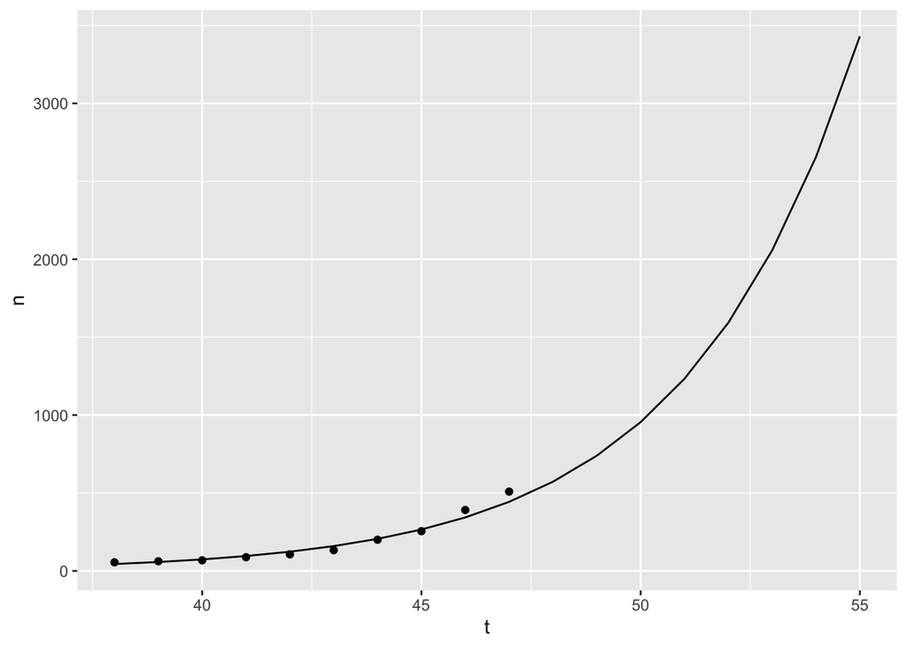

```r
# a few tests
thisname="Mainland China"
thisname="US"
prevs = extractPrevRegion(thisname)

myfore=getForecast(prevs,mode="exp")

ggplot(data=myfore$thedata,aes(x=t,y=n))+geom_point() +
  geom_line(data=myfore$myfore, aes(x=t,y=n))
```

Create the forecasts. Collect into a data frame

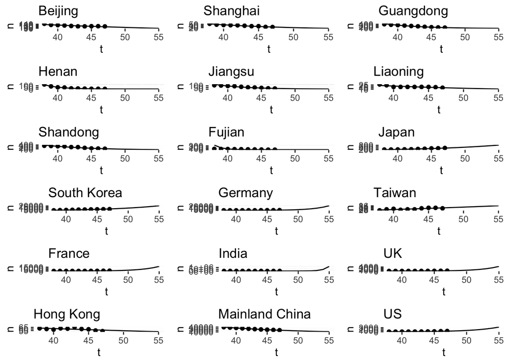

```r
allnames = c(airChina_names, airCountries, "Mainland China", "US")
allfores = lapply( allnames,
        function(thisone) {prevs=extractPrevRegion(thisone)
        return(getForecast(prevs,mode="exp"))})

plotlist=list()
for (k in 1:length(allnames)) {
plotlist[[k]] = ggplot(data=allfores[[k]]$thedata,aes(x=t,y=n))+geom_point() +
  geom_line(data=allfores[[k]]$myfore, aes(x=t,y=n))+ggtitle(allnames[k])}

plot_grid(plotlist=plotlist, ncol = 3)
```

```r
ggsave(file="quickforecasts.pdf", width=8,height=11)
```

Actually they look fine. Collect into a data frame.

```r
forecastdf = data.frame(days=allfores[[1]]$myfore$t,
        dates=seq.Date(from=dates[min(allfores[[1]]$myfore$t)],
                       by=1, length.out=length(allfores[[1]]$myfore$t)))
for (k in 1:length(allnames)) {
  forecastdf[,k+2]=allfores[[k]]$myfore$n
}
colnames(forecastdf)[3:ncol(forecastdf)] = allnames
```

## SIR likelihood model: fail! Ignore.

In this part I explored fitting an SIR model to each dataset but I soon realised that in China, cases were first driven by importations, so this would not fit well. The best way to do that would be a meta-pop model w great travel data, but I doubt it would actually give better short-term forecasts.

```r
sirmodel <- function(t,state,pars) {
  with(as.list(c(state,pars)), {
    dSdt = -(R0/D)*I*S/N
    dIdt = (R0/D)*I*S/N - I/D
    # dRdt = I/D; dr + ds + di =0, S+I+R = N --> R = N-S-I and we eliminate R
     list(c(dSdt, dIdt))
  })
}
```

```r
N=1e6
state=c(S=N-1, I=1)
times = seq(0,50, by=0.1)
pars=list(N=N,D=14,R0=2.5,D=15)
out = as.data.frame(ode(y= state, times=times,  func=sirmodel, parms=pars))
```

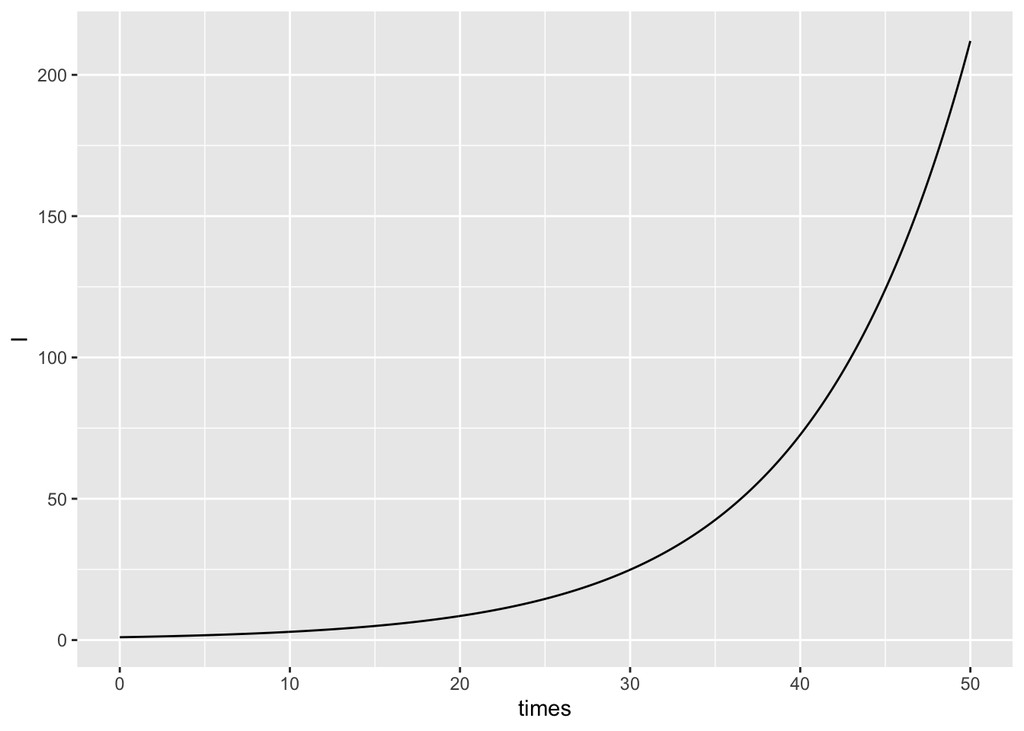

```r
ggplot(data=out, aes(x=times,y=I))+geom_line()
```

Likelihood model: Poisson observations, with mean of I integrated over the day in question

```r
getlambd = function(out,pars,day) {
  try(if(var(diff(out$time)) >0.005) {  stop("approx integral assumes equal time steps")} )
 try(if( max(out$time) < day) {stop("model simulation is not long enough for the data") })
   if (day==min(out$time)) {ii =  which(out$time >= day & out$time < day+1)
   } else {   ii = which(out$time > day-1 & out$time <= day) }

  dx=out$time[ii[2]]-out$time[ii[1]] # like dt
# ft=with(pars , {(Lwi/N)*(out$E[ii] + out$I[ii])})
  ft = out$I[ii]*out$S[ii]*pars$R0/(pars$D*pars$N) # beta i s
return( 0.5*(dx)*(ft[1]+2*sum(ft[2:(length(ft)-1)])+ft[length(ft)])) # numerical int
}

sirloglike = function( out,pars,thisdata) {
  # get expected number of cases each day from the Poisson model and the sim'n
  ld=vapply(thisdata$day, function(x) getlambd(out,pars,x), FUN.VALUE = 1)

  # now call the log likelihood function; thisdata$xd has to be the new cases that day
  return( sum((-ld) + thisdata$xd*(log(ld)) - log( factorial(thisdata$xd))))
  }

loglike = function(R0, pars, thisdata, state,times) {
  pars$R0 = R0
  out = as.data.frame(ode(y= state, times=times,  func=sirmodel, parms=pars))
  return(-sirloglike(out,pars,thisdata))
  # NOTE optim will minimize by default, min ( -loglike) = max (log like)
}
```

Will have to deal with time of starting but for now let’s try just one.

I will need populations. And anyway I fear that all of this is due to importation and I don’t have a metapopn model, nor do I want to make one

```r
popdata=read.csv("~/Hazard/data/population_data.csv",stringsAsFactors = F)
```

```r
myfit=optim(2.5, function(R0) loglike(R0, pars, thisdata,state,times),method = "Brent",lower=1, upper=6)
fitpars= pars; pars$R0=myfit$par
mysol=as.data.frame(ode(y= state, times=times,  func=sirmodel, parms=fitpars))
plot(mysol$time,mysol$I)
```

[output not shown]

And … I conclude that this is Not A Good Model. This explains why the multi-R0 estimates did not work, too.